# Final

### Correlation Analysis

```r
# Correlation matrix (excluding non-numeric columns)
cor(laptop_data[, c("Inches", "Ram", "Memory_GB", "Weight", "Price", "ScreenR_X", "ScreenR_Y", "Cpu_GHz")])
```

```
##                Inches       Ram    Memory_GB      Weight      Price
## Inches     1.00000000 0.2379928  0.034483874  0.82763110 0.06819667
## Ram        0.23799280 1.0000000  0.082256797  0.38387409 0.74300714
## Memory_GB  0.03448387 0.0822568  1.000000000  0.02043971 0.05181393
## Weight     0.82763110 0.3838741  0.020439715  1.00000000 0.21036980
## Price      0.06819667 0.7430071  0.051813934  0.21036980 1.00000000
## ScreenR_X -0.07124533 0.4331205  0.009917865 -0.03287982 0.55652933
## ScreenR_Y -0.09540391 0.4244366  0.008352001 -0.05384565 0.55280922
## Cpu_GHz    0.30786980 0.3680005 -0.013107366  0.32043359 0.43029310
##              ScreenR_X    ScreenR_Y     Cpu_GHz
## Inches    -0.071245329 -0.095403915  0.30786980
## Ram        0.433120528  0.424436650  0.36800048
## Memory_GB  0.009917865  0.008352001 -0.01310737
## Weight    -0.032879824 -0.053845653  0.32043359
## Price      0.556529329  0.552809220  0.43029310
## ScreenR_X  1.000000000  0.994218960  0.18354831
## ScreenR_Y  0.994218960  1.000000000  0.16966792
## Cpu_GHz    0.183548313  0.169667918  1.00000000
```

The correlation analysis reveals that larger screen sizes (Inches) are strongly positively correlated with increased laptop weight, while higher RAM capacity correlates positively with elevated laptop prices; however, there is only a weak correlation between storage capacity (Memory_GB) and price.

### Scatter Plots

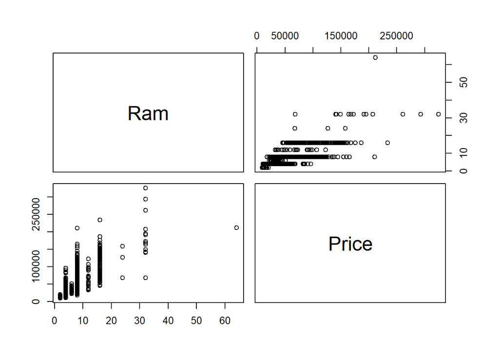

```r
pairs(laptop_data[, c("Ram","Price")])
```

This chart shows the strong positive relationship between RAM and price.

## 3) Use some “visualization techniques” and talk about your data further.

Histogram Histogram analysis is an important method that helps us understand the shape, center and spread of data.

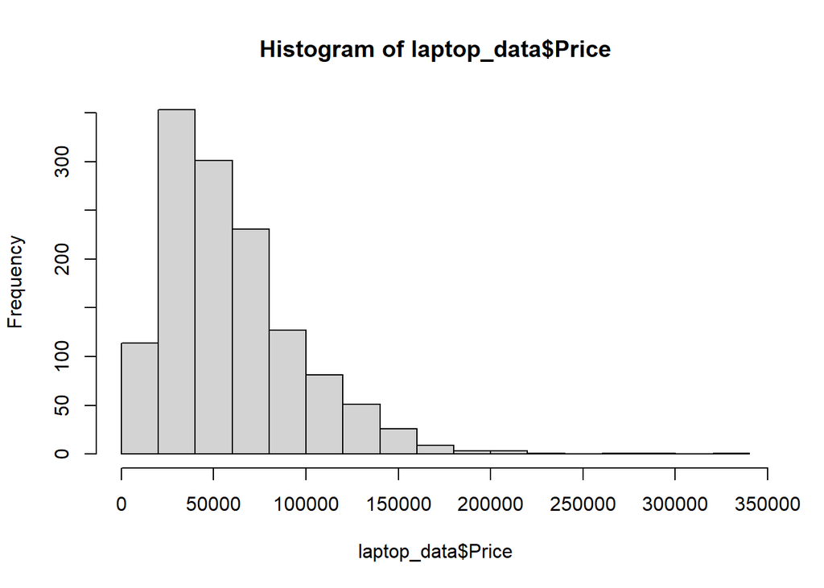

```r
hist(laptop_data$Price)
```

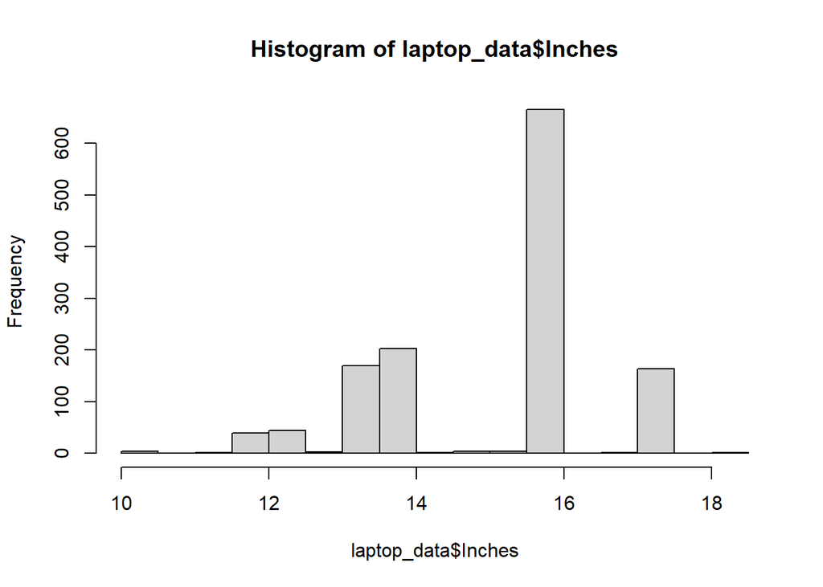

```r
hist(laptop_data$Inches)
```

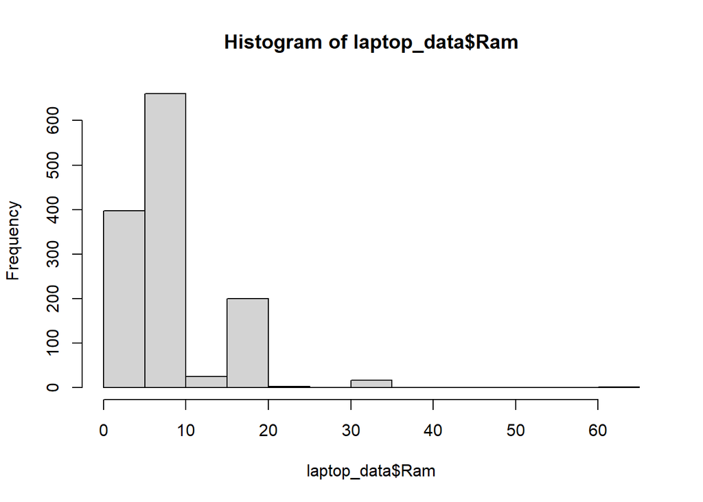

```r
hist(laptop_data$Ram)
```